# LifeGenMon Abies SNP analysis

### Principal Component Analysis (PCA)

```r
## In case there are missing data, replace with mean
X <- tab(obj, freq = TRUE, NA.method = "mean")

pca.obj <- dudi.pca(X, scale = FALSE, scannf = FALSE, nf = 3)

fviz_eig(pca.obj, main = "Scree plot of PCA")
```

[output not shown]

```r
ggord(pca.obj, pop(obj), arrow = NULL, txt = NULL,
      grp_title="Populations", ellipse=T, poly=FALSE, size=2,
      alpha=.8, coord_fix=F, axes = c("1", "2")) +
  geom_hline(yintercept=0,linetype=2) +
  geom_vline(xintercept=0,linetype=2) +
  ggtitle("Principal Component Analysis") +
  scale_shape_manual('Groups', values = 0:5) +
  scale_color_manual('Groups', values =
                       c('#1b9e77','#d95f02','#7570b3',
                         '#e7298a','#66a61e','#e6ab02') )

# ggord(pca.obj, pop(obj), arrow = NULL, txt = NULL,
# grp_title="Populations", ellipse=T, poly=FALSE, size=2,
# alpha=.8, coord_fix=F, axes = c("1", "3")) +
#   geom_hline(yintercept=0,linetype=2) +
#   geom_vline(xintercept=0,linetype=2) +
#   ggtitle("Principal Component Analysis") +
#   scale_shape_manual('Groups', values = 0:5) +
#   scale_color_manual('Groups', values =
#                        c('#1b9e77','#d95f02','#7570b3',
#                          '#e7298a','#66a61e','#e6ab02') )
```

[output not shown]

### Correspondence Analysis

```r
ca1 <- dudi.coa(tab(obj, freq = TRUE, NA.method = "mean"), scannf=FALSE,nf=3)

fviz_eig(ca1, main = "Scree plot of CA")
```

[output not shown]

```r
# devtools::install_github('fawda123/ggord')

ggord(ca1, pop(obj), arrow = NULL, txt = NULL,
      grp_title="Populations", ellipse=T, poly=FALSE,
      size=2, alpha=.8, coord_fix=F, axes = c("1", "2")) +
  geom_hline(yintercept=0,linetype=2) +
  geom_vline(xintercept=0,linetype=2) +
  ggtitle("Correspondence Analysis")  +
  scale_shape_manual('Groups', values = 0:5) +
  scale_color_manual('Groups', values =
                       c('#1b9e77','#d95f02','#7570b3',
                         '#e7298a','#66a61e','#e6ab02') )

# ggord(ca1, pop(obj), arrow = NULL, txt = NULL,
# grp_title="Populations", ellipse=T, poly=FALSE,
# size=2, alpha=.8, coord_fix=F, axes = c("1", "3")) +
#   geom_hline(yintercept=0,linetype=2) +
#   geom_vline(xintercept=0,linetype=2) +
#   ggtitle("Correspondence Analysis")
#   #scale_colour_brewer(palette="Set3")

# loadingplot(ca1$c1^2, threshold = 8)
```

[output not shown]

### AMOVA

```r
# setPop(obj) <- ~Country

poppr.amova(obj, ~Country, within = F)
```

[output not shown]

### Hierarchical AMOVA

```r
# setPop(obj) <- ~Country/Pop

poppr.amova(obj, ~Country/Pop, within = F)
```

[output not shown]

### Hierarchical AMOVA - within variation included (as calculated using Arlequin)

```r
### Hierarchical AMOVA - within variation included (as calculated using Arlequin)
poppr.amova(obj, ~Country/Pop, within = T)
```

[output not shown]

### IBD

```r
#change hierarchy to country level
setPop(obj) <- ~Country

# obj_pop <- genind2genpop(obj)
# Dgen <- dist.genpop(obj_pop,method=2) #maybe only with genepop object

# compute cavalli-sforza distance
Dgen <- genet.dist(obj, method = "Dch")
# theoretically any genetic distance can be used
# Dgeo <- dist(obj_pop$other$xy)
geo <- data.frame(popNames(obj))
x <- c(47.81, 40.09, 46.09)
y <- c(12.87, 22.44, 14.29)
geo$x <- x
geo$y <- y
Dgeo <- dist(geo)

ibd <- mantel.randtest(Dgen,Dgeo)
ibd

# plot(ibd)

# library(MASS)
# dens <- kde2d(Dgeo,Dgen, n=300)
# myPal <- colorRampPalette(c("white","blue","gold", "orange", "red"))
# plot(Dgeo, Dgen, pch=20,cex=.5,
#      ylab="Cavalli-Sforza genetic distance",
#      xlab="Geographical distance (euclidean)")
# image(dens, col=transp(myPal(300),.7), add=TRUE)
# abline(lm(Dgen~Dgeo))
# title("Isolation by distance")

plot(Dgeo, Dgen, pch=20,cex=.5,
     ylab="Cavalli-Sforza genetic distance",
     xlab="Geographical distance (euclidean)")
abline(lm(Dgen~Dgeo))
title("Isolation by distance")

#reset hierarchy
setPop(obj) <- ~Country/Pop
```

[output not shown]

```r
library(ecodist)

mantel(Dgen ~ Dgeo)
```

[output not shown]

### Structure

#### 1000 Burn-in iterations, 5000 MCMC repititions

#### ATTN! A lower than optimal number of repititions was used, due to computational constrains.

#### Repeating the analysis using a higher number of repitions is required to ensure its robustness.

```r
#change hierarchy
setPop(obj) <- ~Country/Pop
```

```r
## Convert input file
        loci <- genind2loci(obj)

        ## obj_g <- genind2gtypes(obj)
        obj_g <- loci2gtypes(loci)

struct <- structureRun(obj_g, k = 2:6, num.k.rep = 5,
                            burnin = 1000, numreps = 5000, noadmix = F,
                            freqscorr = T,
                            ## pop.prior = ,
                            ## locpriorinit = , maxlocprior = , ## locprior
                            ## gensback = , migrprior = , ## usepopinfo
                            ## pfrompopflagonly = , popflag = , ## usepopinfo
                            ## pops = c(""),
                            delete.files = F)

## ## Evanno deltaK
## evanno(gano.struct)
##
## ## clumpp
## gano.clumpp <- clumpp(gano.struct, k=5,
##                       delete.files = F)
##
## ## show membership using strataG
## sp <- structurePlot(gano.clumpp, horiz = FALSE)
```

#### Tests for optimal K

```r
## read structure runs from pophelper
sfiles <- list.files(path = "../results/gtypes.created.on.2019.04.27.21.33.22.structureRun/",
                     pattern = "out_f", full.names = T, recursive = T)

        ## include individual names from STRUCTURE file as row names
slist <- readQ(files=sfiles, indlabfromfile=T)

## Evanno pophelper
sr1 <- summariseQ(tabulateQ(slist))
p <- evannoMethodStructure(data=sr1,exportplot=F,returnplot=T,
                           returndata=F,basesize=12,linesize=0.7)
```

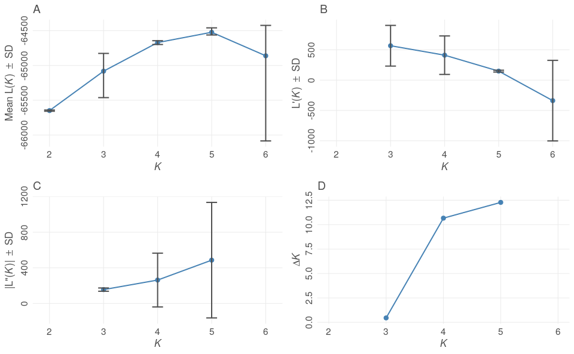

```r
grid.arrange(p)
```

```r
## clumpp through pophelper
## clumppExport(qlist=slist[16:20], useexe=T)

## show membership using pophelper
## read aligned file
## aligned <- readQ("./pop_K5/pop_K5-combined-aligned.txt")

## plot
## copy & paste the population column from genalex input file to a csv
# pop_labs <- read.delim("Castanea_SSR_HRM_pops.csv",
#                        header=F,stringsAsFactors=F)

loci <- genind2loci(obj)

pop_labs <- data.frame(loci[,1], stringsAsFactors = F)
names(pop_labs) <- "Pop"
pop_labs$Pop <- as.character(pop_labs$Pop)

## FOR MORE COLOR COMBINATIONS CHECK:
## http://colorbrewer2.org/##type=diverging&scheme=BrBG&n=4
clist <- list(
        "shiny"=c("#1D72F5","#DF0101","#77CE61", "#FF9326","#A945FF","#0089B2","#FDF060","#FFA6B2","#BFF217","#60D5FD","#CC1577","#F2B950","#7FB21D","#EC496F","#326397","#B26314","#027368","#A4A4A4","#610B5E"),
        "strong"=c("#11A4C8","#63C2C5","#1D4F9F","#0C516D","#2A2771","#396D35","#80C342","#725DA8","#B62025","#ED2224","#ED1943","#ED3995","#7E277C","#F7EC16","#F8941E","#8C2A1C","#808080"),
        "oceanfive"=c("#00A0B0", "#6A4A3C", "#CC333F", "#EB6841", "#EDC951"),
        "keeled"=c("#48B098", "#91CB62", "#FFEE3B", "#FB9013", "#FF3C28"),
        "vintage"=c("#400F13", "#027368", "#A3BF3F", "#F2B950", "#D93A2B"),
        "muted"=c("#46BDDD","#82DDCE","#F5F06A","#F5CC6A","#F57E6A"),
        "teal"=c("#CFF09E","#A8DBA8","#79BD9A","#3B8686","#0B486B"),
        "merry"=c("#5BC0EB","#FDE74C","#9BC53D","#E55934","#FA7921"),
        "funky"=c("#A6CEE3", "#3F8EAA", "#79C360", "#E52829", "#FDB762","#ED8F47","#9471B4"),
        "retro"=c("#01948E","#A9C4E2","#E23560","#01A7B3","#FDA963","#323665","#EC687D"),
        "cb_paired"=c("#A6CEE3","#1F78B4","#B2DF8A","#33A02C","#FB9A99","#E31A1C","#FDBF6F","#FF7F00","#CAB2D6","#6A3D9A","#FFFF99","#B15928"),
        "cb_set3"=c("#8DD3C7","#FFFFB3","#BEBADA","#FB8072","#80B1D3","#FDB462","#B3DE69","#FCCDE5","#D9D9D9","#BC80BD","#CCEBC5","#FFED6F"),
        "morris"=c("#4D94CC","#34648A","#8B658A","#9ACD32","#CC95CC","#9ACD32","#8B3A39","#CD6601","#CC5C5B","#8A4500"),
        "wong"=c("#000000","#E69F00","#56B4E9","#009E73","#F0E442","#006699","#D55E00","#CC79A7"),
        "krzywinski"=c("#006E82","#8214A0","#005AC8","#00A0FA","#FA78FA","#14D2DC","#AA0A3C","#FA7850","#0AB45A","#F0F032","#A0FA82","#FAE6BE"))

p2 <- plotQ(slist[1],returnplot=T,exportplot=F,quiet=T,basesize=11,
            # showindlab=T, useindlab=T,
            ## indlabwithgrplab=T,
            showsp = T, splab = "K=2", splabsize = 11,
            showyaxis=T,
            # showticks=T, ticksize=0.3, ticklength=0.2 ## y axis
            ,panelspacer=0.4,
            grplab = pop_labs,
            grplabsize=4, linesize=0.8, pointsize=4,
            ## sortind="all",
            divgrp = "Pop", divsize=0.5,
            clustercol=clist$wong,
            panelratio=c(11,1))

## grid.arrange(p2$plot[[1]])

p3 <- plotQ(slist[6],returnplot=T,exportplot=F,quiet=T,basesize=11,
            # showindlab=T, useindlab=T,
            ## indlabwithgrplab=T,
            showsp = T, splab = "K=3", splabsize = 11,
            showyaxis=T,
            # showticks=T, ticksize=0.3, ticklength=0.2 ## y axis
            ,panelspacer=0.4,
            grplab = pop_labs,
            grplabsize=4, linesize=0.8, pointsize=4,
            ## sortind="all",
            divgrp = "Pop", divsize=0.5,
            clustercol=clist$wong,
            panelratio=c(11,1))

## grid.arrange(p3$plot[[1]])
```

```r
## A new chunk was created for plotting to avoid producing an empty plot
## https://support.rstudio.com/hc/en-us/community/posts/239529128-Notebooks-grid-newpage
grid.arrange(p2$plot[[1]])
```

[output not shown]

```r
grid.arrange(p3$plot[[1]])
```

[output not shown]

```r
#reset hierarchy
setPop(obj) <- ~Country/Pop
```

# Ne estimation

Estimate Ne from linkage disequilibrium based on Pearson correlation approximation following [@waples_EstimatingContemporaryEffective_2016].

ATTN! Check if some loci should be removed in case of LD

```r
## Convert input file
        loci <- genind2loci(obj)

        ## obj_g <- genind2gtypes(obj)
        obj_g <- loci2gtypes(loci)
```

```r
#' @title ldNe
#' @description Estimate Ne from linkage disequilibrium based on Pearson
#'   correlation approximation following Waples et al 2016. Adapted from code
#'   by R. Waples and W. Larson.
#'
#' @param g a \linkS4class{gtypes} object.
#' @param maf.threshold smallest minimum allele frequency permitted to include
#'   a locus in calculation of Ne.
#' @param by.strata apply the \code{maf.threshold} by strata. If \code{TRUE}
#'   then any locus that is below this threshold in any strata will be removed
#'   from the calculation of Ne for every stratum. Otherwise, loci are removed
#'   only if they are below the \code{maf.threshold} in the stratum for which
#'   Ne is calculated.
#' @param ci central confidence interval.
#'
#' @return a numeric matrix with one row per strata and the following columns:
#' \describe{
#'  \item{\code{S}}{harmonic mean of sample size across pairwise comparisons of loci}
#'  \item{\code{num.comp}}{number of pairwise loci comparisons used}
#'  \item{\code{mean.rsq}}{mean r^2 over all loci}
#'  \item{\code{mean.E.rsq}}{mean expected r^2 over all loci}
#'  \item{\code{Ne}}{estimated Ne}
#'  \item{\code{param.lci, param.uci}}{parametric lower and upper CIs}
#' }
#'
#' @references Waples, R.S. 2006. A bias correction for estimates of effective population
#'   size based on linkage disequilibrium at unlinked gene loci.
#'   Conservation Genetics 7:167-184. \cr\cr
#'   Waples RK, Larson WA, and Waples RS. 2016. Estimating contemporary
#'   effective population size in non-model species using linkage
#'   disequilibrium across thousands of loci. Heredity 117:233-240;
#'   doi:10.1038/hdy.2016.60
#'
#' @author Eric Archer \email{eric.archer@@noaa.gov}
#'
#' @importFrom parallel mclapply detectCores
#' @importFrom stats cor qchisq
#' @export
#'
ldNe <- function(g, maf.threshold = 0, by.strata = FALSE, ci = 0.95) {
  if(ploidy(g) != 2) stop("'g' must have diploid data")

  # remove non-biallelic loci
  num.alleles <- numAlleles(g)
  biallelic <- names(num.alleles)[num.alleles <= 2]
  if(length(biallelic) == 0) {
    warning("No loci are biallelic. NULL returned.", call. = FALSE)
    return(NULL)
  }
  g <- g[, biallelic, ]

  # remove loci if below maf threshold for any stratum
  if(maf.threshold > 0 & by.strata) {
    maf.g <- maf(g, by.strata = TRUE)
    above.thresh <- which(apply(maf.g, 2, function(x) all(x >= maf.threshold)))
    if(length(above.thresh) < 2) {
      warning(
        paste0("Fewer than two loci are above 'maf.threshold' in any stratum. NULL returned."),
        call. = FALSE
      )
      return(NULL)
    }
    g <- g[, above.thresh, ]
  }

  # calculate Pearson r-squared between a pair of loci
  compLoc <- function(i, loc.pairs, mat) {
    pair.mat <- mat[, loc.pairs[, i]]
    pair.mat <- pair.mat[complete.cases(pair.mat), , drop = FALSE]
    rsq <- cor(pair.mat[, 1], pair.mat[, 2], method = "pearson") ^ 2
    S <- nrow(pair.mat)
    c(S = S, rsq = rsq)
  }

  # Eqn 1.7: calculate Ne
  calcNe <- function(S, Rsq.drift) {
    if(S > 29) {
      root.term <- 1 / 9 - 2.76 * Rsq.drift
      if(root.term < 0) root.term <- 0
      (1 / 3 + sqrt(root.term)) / (2 * Rsq.drift)
    } else {
      root.term <- 0.308 ^ 2 - 2.08 * Rsq.drift
      if(root.term < 0) root.term <- 0
      (0.308 + sqrt(root.term)) / (2 * Rsq.drift)
    }
  }

  # calculate Ne by strata
  ne.smry <- sapply(strataSplit(g), function(g.st) {
    # remove loci below MAF threshold
    if(maf.threshold > 0) {
      above.thresh <- which(maf(g.st) >= maf.threshold)
      if(length(above.thresh) < 2) {
        warning(
          paste0("Fewer than two loci are above 'maf.threshold' in '", strataNames(g.st), "'"),
          call. = FALSE
        )
        return(NULL)
      }
      g.st <- g.st[, above.thresh, ]
    }

    # create list of coded numeric matrices for each stratum
    g.mat <- as.matrix(g.st, ids = FALSE, strata = FALSE)
    mat <- matrix(nrow = nInd(g.st), ncol = nLoc(g.st))
    a1.i <- seq(1, ncol(g.mat), by = 2)
    for(j in 1:length(a1.i)) {
      a1 <- a1.i[j]
      mat.j <- g.mat[, c(a1, a1 + 1), drop = FALSE]
      alleles <- sort(unique(mat.j))
      for(i in 1:nrow(mat.j)) mat[i, j] <- sum(mat.j[i, ] == alleles[1])
    }

    # remove loci that are constant
    mat <- mat[, apply(mat, 2, function(x) var(x) > 0), drop = FALSE]
    if(ncol(mat) < 2) {
      warning(
        paste0("Fewer than two loci have more than one genotype in '", strataNames(g.st), "'"),
        call. = FALSE
      )
      return(NULL)
    }

    # calculate correlation r-squared (rsq) between pairs of loci
    loc.pairs <- combn(ncol(mat), 2)
    loc.comp.mat <- mclapply(1:ncol(loc.pairs), compLoc, loc.pairs = loc.pairs, mat = mat, mc.cores = detectCores() - 1)
    loc.comp.mat <- do.call(cbind, loc.comp.mat)
    to.keep <- apply(loc.comp.mat, 2, function(x) all(!is.na(x)))
    if(sum(to.keep) == 0) stop("all loci have missing data")
    loc.comp.mat <- loc.comp.mat[, to.keep, drop = FALSE]

    # cl <- .setupClusters()
    # loc.comp.mat <- tryCatch({
    #   if(!is.null(cl)) {
    #     parSapply(cl, 1:ncol(loc.pairs), compLoc, loc.pairs = loc.pairs, mat = mat)
    #   } else {
    #     sapply(1:ncol(loc.pairs), compLoc, loc.pairs = loc.pairs, mat = mat)
    #   }
    # }, finally = if(!is.null(cl)) stopCluster(cl))

    S <- loc.comp.mat["S", ]
    # Eqn 1.1: expected r-squared
    E.rsq <- ifelse(S > 29, (1 / S) + (3.19 / S ^ 2), 0.0018 + (0.907 / S) + (4.44 / S ^ 2))
    # sample size corrected r-squared
    rsq <- loc.comp.mat["rsq", ] * ((S / (S - 1)) ^ 2)
    # Eqn 1.4
    w <- S ^ 2
    # Eqn 1.5
    W <- sum(w)
    mean.rsq <- sum(w * rsq) / W
    # Eqn 1.6
    Rsq.drift <- rsq - E.rsq
    # Eqn 1.10: R-squared prime.0 for Ne.0
    Rsq.drift.0 <- sum(Rsq.drift * w) / W
    # harmonic mean of S
    N <- ncol(loc.comp.mat)
    S.harm.mean <- N / sum(1 / S)
    # initial Ne.0
    ne0 <- calcNe(S.harm.mean, Rsq.drift.0)

    # Eqn 1.11: R-squared prime weights
    wt <- S ^ 2 / (S + 3 * ne0) ^ 2
    # Eqn 1.12: weighted R-squared prime
    Rsq.drift <- sum(wt * Rsq.drift) / sum(wt)

    # mean expected r-squared
    mean.E.rsq <- sum(w * E.rsq) / W

    # calculate CI
    lci.p <- (1 - ci) / 2
    uci.p <- 1 - lci.p
    Rsq.drift.lci <- mean.rsq * N / qchisq(lci.p, N) - mean.E.rsq
    Rsq.drift.uci <- mean.rsq * N / qchisq(uci.p, N) - mean.E.rsq

    ne <- calcNe(S.harm.mean, Rsq.drift)
    param.lci <- calcNe(S.harm.mean, Rsq.drift.lci)
    param.uci <- calcNe(S.harm.mean, Rsq.drift.uci)
    if(ne < 0) ne <- Inf
    if(param.lci < 0) param.lci <- Inf
    if(param.uci < 0) param.uci <- Inf

    c(
      S = S.harm.mean, num.comp = N, mean.rsq = mean.rsq,
      mean.E.rsq = mean.E.rsq, Ne = ne, param.lci = param.lci,
      param.uci = param.uci
    )
  }, USE.NAMES = TRUE, simplify = FALSE)
  ne.smry <- ne.smry[!sapply(ne.smry, is.null)]
  do.call(rbind, ne.smry)
}
```

```r
library(parallel)

Ne_0 <- ldNe(obj_g, maf.threshold = 0, by.strata = F, ci = 0.95)
Ne_0 <- as.data.frame(Ne_0)

Ne_0 <- add_column(Ne_0, population = popNames(obj), .before = "S")
Ne_0
```

[output not shown]

```r
Ne_0.05 <- ldNe(obj_g, maf.threshold = 0.01, by.strata = F, ci = 0.95)
Ne_0.05 <- as.data.frame(Ne_0.05)

Ne_0.05 <- add_column(Ne_0.05, population = popNames(obj), .before = "S")
Ne_0.05
```

[output not shown]

```r
knitr::kable(Ne_0, format = "html", digits = 3) %>%
  kable_styling(bootstrap_options = "striped", full_width = F)

# ggplot(Ne, aes(x=population, y=Ne)) +
#   geom_point(stat = "identity",
#            color="black", fill = "lightgrey",
#            size = 2) +
#   scale_y_continuous(breaks = seq(0, 10000, 500)) +
#   geom_errorbar(aes(ymin=param.lci, ymax=param.uci),
#                 width = .3) +
#   ggtitle("Ne (95% CIs)") +
#   theme_classic()
```

[output not shown]

```r
library(parallel)

ldNe(obj_g,maf.threshold = 0, by.strata = F, ci = 0.95)
```

[output not shown]

```r
to.remove <- as.vector(LD_sig_intersect$locus1[-3])

loci_int <- names(nAll(obj))

obj_no_LD <- obj[,loc = setdiff(loci_int, to.remove)]
```

```r
# Convert input file
        loci_no_LD <- genind2loci(obj_no_LD)

        ## obj_g <- genind2gtypes(obj)
        obj_g_no_LD <- loci2gtypes(loci_no_LD)
```

```r
Ne_0_no_LD <- ldNe(obj_g_no_LD, maf.threshold = 0, by.strata = F, ci = 0.95)
Ne_0_no_LD <- as.data.frame(Ne_0_no_LD)

Ne_0_no_LD <- add_column(Ne_0_no_LD, population = popNames(obj), .before = "S")
Ne_0_no_LD
```

[output not shown]

# Notes

- Some SNPs are only typed for the greek populations, and were not included in this analysis. They should be investigated further.